# XAI 3: Model-Agnostic methods

## EXERCISE:

Apply PDP to the regression example of predicting bike rentals. Fit a random forest approximation for the prediction of bike rentals (**cnt**). Use the partial dependence plot to visualize the relationships the model learned. Use the slides shown in class as model.

## QUESTION:

Analyse the influence of **days since 2011, temperature, humidity** and **wind speed** on the predicted bike counts.

````r
```r

# sampled <- sample_n(......, 40)
````

[output not shown]

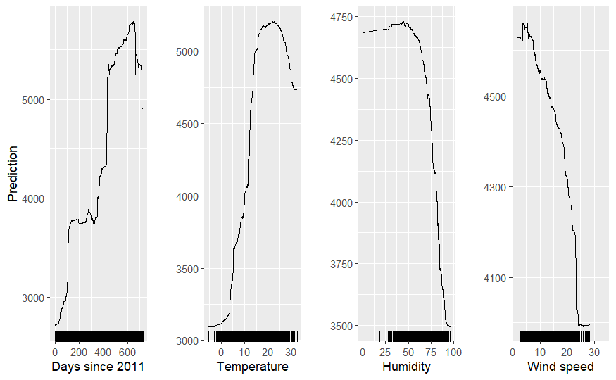

```r
p1 = ggplot(data = days_since) + geom_line(aes(x=days_since_2011,y=results$days_since_2011)) + geom_rug(mapping=aes(x=days_since_2011),sides = "b",inherit.aes=F) + labs(x = "Days since 2011", y="Prediction")

p2 = ggplot(data = days_since) + geom_line(aes(x=temp,y=results$temp)) + geom_rug(mapping=aes(x=temp),sides = "b",inherit.aes=F) + labs(x = "Temperature", y="")

p3 = ggplot(data = days_since) + geom_line(aes(x=hum,y=results$hum)) + geom_rug(mapping=aes(x=hum),sides = "b",inherit.aes=F) + labs(x = "Humidity", y="")

p4 = ggplot(data = days_since) + geom_line(aes(x=windspeed,y=results$windspeed)) + geom_rug(mapping=aes(x=windspeed),sides = "b",inherit.aes=F) + labs(x = "Wind speed", y="")

grid.arrange(p1,p2,p3,p4,nrow=1)
```

In the “Temperature” plot, we can also extract with confidence of our interpretations that this variable follows a quadratic relationship with the number of bikes rented, and we can see that the hotter the day is, the more bikes will be rented, but up to a limit when the number will descend if the day is too hot.

Finaly, with the “Wind speed” plot we can’t assume anything from the higher-up end, as they have fewer samples than the rest of values. We also see that it has an inverse linear relationship with the number of bikes rented, meaning that higher wind speed reduced the number of bikes rented.

## EXERCISE:

Generate a 2D Partial Dependency Plot with humidity and temperature to predict the number of bikes rented depending of those parameters.

BE CAREFUL: due to the size, extract a set of random samples from the BBDD before generating the the data for the Partial Dependency Plot.

Show the density distribution of both input features with the 2D plot as shown in the class slides.

TIP: Use geom_tile() to generate the 2D plot. Set width and height to avoid holes.

```r
sampled <- sample_n(days_since, 40)
temp <- sampled$temp
hum <- sampled$hum
th <- inner_join(data.frame(temp),data.frame(hum), by=character())
th$p <- 0

for(i in 1:nrow(th)){
  r <- days_since
  r[["temp"]] <- th[["temp"]][i]
  r[["hum"]] <- th[["hum"]][i]

  sal <- predict(rf, r)$predicted
  th[["p"]][i] <- sum(sal) / nr
}
```

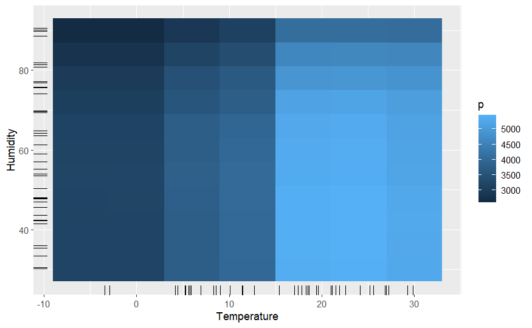

```r
th2 = th
th2$temp = round(th2$temp/6)*6
th2$hum = round(th2$hum/6)*6
ggplot(data = th2, aes(x=temp,y=hum,fill=p)) + geom_tile() + geom_rug(mapping=aes(x=th$temp),sides = "b",inherit.aes=F)+ geom_rug(mapping=aes(y=th$hum),sides = "l",inherit.aes=F) + labs(x = "Temperature", y="Humidity")
```

## QUESTION:

Interpret the results.

We can deduce from this plot that the most important variable in the prediction of bike rents is the temperature. If we observe the higer temperatures we can say with confidence that they are related with a higer number of bikes. We are not so sure about the lower temperatures because we don’t have enough data, but it looks like a lower temperature is related with lower bikes rents. We can also observe that the humidity even though it is not as relevant, it also has a subtle influence in the number of bikes: when we observe really high humidity, the number of bikes decreases, maybe because it implyes rain.

## EXERCISE:

Apply the previous concepts to predict the **price** of a house from the database **kc_house_data.csv**. In this case, use again a random forest approximation for the prediction based on the features **bedrooms**, **bathrooms**, **sqft_living**, **sqft_lot**, **floors** and **yr_built**. Use the partial dependence plot to visualize the relationships the model learned.

BE CAREFUL: due to the size, extract a set of random samples from the BBDD before generating the data for the Partial Dependency Plot.

## QUESTION:

Analyse the influence of **bedrooms, bathrooms, sqft_living** and **floors** on the predicted price.

```r
d <- read.csv("kc_house_data.csv")

sampled <- sample_n(d, 1000)

sampled <- select(sampled, bedrooms, bathrooms, sqft_living, sqft_lot, floors, yr_built, price)

rf <- rfsrc(price~., data=sampled)

results <- select(sampled, bedrooms, bathrooms, sqft_living, floors, price)
nr <- nrow(sampled)
for(c in names(results)[1:4])
{
  for(i in 1:nr){
    r <- sampled
    r[[c]] <- sampled[[c]][i]
    sal <- predict(rf, r)$predicted
    results[[c]][i] <- sum(sal) / nr
  }
}
```